← Back to index

# Linear Gaussian Systems: Blood Pressure Estimation

## Real-World Scenario: Clinical Blood Pressure Assessment

A patient visits their doctor for a routine checkup. The doctor wants to estimate the patient's **true underlying blood pressure** (systolic and diastolic) - this is our **latent state** $\mathbf{z} \in \mathbb{R}^2$.

The doctor has two sources of information:

- **Prior belief**: The patient's historical blood pressure records from previous visits
- **Current measurements**: Multiple readings taken today with different devices (automatic cuff, manual sphygmomanometer, wrist monitor)

Each measurement device provides **noisy readings** due to:

- Measurement error inherent to the device
- Patient's momentary state (anxiety, recent activity)
- Technique variations

Our goal: Combine prior knowledge with noisy measurements to get the best estimate of true blood pressure using **Bayes rule for Gaussians**.

## Mathematical Framework (Chapter 3.3.1)

### Linear Gaussian System

**Prior over true blood pressure:** $$p(\mathbf{z}) = \mathcal{N}(\mathbf{z} | \boldsymbol{\mu}_z, \boldsymbol{\Sigma}_z)$$

**Likelihood (measurement model):** $$p(\mathbf{y}|\mathbf{z}) = \mathcal{N}(\mathbf{y} | \mathbf{W}\mathbf{z} + \mathbf{b}, \boldsymbol{\Sigma}_y)$$

where:

- $\mathbf{z} \in \mathbb{R}^L$ is the true blood pressure (L=2: systolic, diastolic)
- $\mathbf{y} \in \mathbb{R}^D$ is the vector of measurements (D=3 devices × 2 values = 6)
- $\mathbf{W}$ is a $D \times L$ matrix mapping true BP to expected measurements
- $\mathbf{b}$ is a bias vector (device calibration offsets)
- $\boldsymbol{\Sigma}_y$ is the measurement noise covariance

### Bayes Rule for Gaussians (Eq. 3.37)

**Posterior:** $$p(\mathbf{z}|\mathbf{y}) = \mathcal{N}(\mathbf{z} | \boldsymbol{\mu}_{z|y}, \boldsymbol{\Sigma}_{z|y})$$

where: $$\boldsymbol{\Sigma}_{z|y}^{-1} = \boldsymbol{\Sigma}_z^{-1} + \mathbf{W}^T \boldsymbol{\Sigma}_y^{-1} \mathbf{W}$$

$$\boldsymbol{\mu}_{z|y} = \boldsymbol{\Sigma}_{z|y} \left[ \mathbf{W}^T \boldsymbol{\Sigma}_y^{-1} (\mathbf{y} - \mathbf{b}) + \boldsymbol{\Sigma}_z^{-1} \boldsymbol{\mu}_z \right]$$

```python
import numpy as np
import matplotlib.pyplot as plt
from scipy.stats import multivariate_normal
from matplotlib.patches import Ellipse

np.random.seed(42)

# Set up nice plotting
plt.rcParams['figure.figsize'] = [12, 8]
plt.rcParams['font.size'] = 12
```

## 1. Define the Clinical Scenario

```python
# =============================================================================
# LATENT SPACE (2D): True underlying blood pressure
# =============================================================================
L = 2  # Latent dimension: [systolic, diastolic]

# True (unknown) blood pressure we want to estimate
# Patient has mild hypertension
z_true = np.array([138.0, 88.0])  # True systolic=138, diastolic=88 mmHg

# Prior belief: Based on patient's historical records from last 3 visits
# Previous readings: (135, 85), (140, 90), (132, 82) -> average around (136, 86)
mu_z = np.array([136.0, 86.0])  # Prior mean from medical history

# Prior covariance: Reflects typical visit-to-visit variability
# Systolic varies more than diastolic, and they're positively correlated
Sigma_z = np.array([[64.0, 20.0],   # Variance in systolic = 64 (SD = 8 mmHg)
                    [20.0, 25.0]])  # Variance in diastolic = 25 (SD = 5 mmHg)

print("=" * 60)
print("PATIENT PROFILE - True Blood Pressure (Unknown to Doctor)")
print("=" * 60)
print(f"True BP z* = {z_true[0]:.0f}/{z_true[1]:.0f} mmHg")
print(f"\nPrior from medical history:")
print(f"  Mean μ_z = {mu_z[0]:.0f}/{mu_z[1]:.0f} mmHg")
print(f"  Std dev = {np.sqrt(Sigma_z[0,0]):.1f}/{np.sqrt(Sigma_z[1,1]):.1f} mmHg")
print(f"  Correlation = {Sigma_z[0,1]/np.sqrt(Sigma_z[0,0]*Sigma_z[1,1]):.2f}")
```

```
============================================================
PATIENT PROFILE - True Blood Pressure (Unknown to Doctor)
============================================================
True BP z* = 138/88 mmHg

Prior from medical history:
  Mean μ_z = 136/86 mmHg
  Std dev = 8.0/5.0 mmHg
  Correlation = 0.50
```

```python
# =============================================================================
# OBSERVATION SPACE (6D): Measurements from 3 devices
# =============================================================================
# Each device measures both systolic and diastolic
# Device 1: Automatic arm cuff (standard clinical device)
# Device 2: Manual sphygmomanometer (gold standard, but technique-dependent)
# Device 3: Wrist monitor (convenient but less accurate)

D = 6  # Observation dimension: 3 devices × 2 measurements each

# W matrix: Maps true BP [systolic, diastolic] to 6 measurements
# Each device directly measures both values (identity-like structure)
W = np.array([
    [1.0, 0.0],   # Device 1: systolic
    [0.0, 1.0],   # Device 1: diastolic
    [1.0, 0.0],   # Device 2: systolic
    [0.0, 1.0],   # Device 2: diastolic
    [1.0, 0.0],   # Device 3: systolic
    [0.0, 1.0],   # Device 3: diastolic
])

# b vector: Device calibration biases
# Device 1: well-calibrated, minimal bias
# Device 2: tends to read slightly high
# Device 3: wrist monitor has position-dependent bias
b = np.array([0.0, 0.0,    # Device 1: no bias
              2.0, 1.0,    # Device 2: reads +2/+1 mmHg high
              -3.0, 2.0])  # Device 3: systolic low, diastolic high

# Observation noise covariance (block diagonal for independent devices)
# Device 1: Good precision (automatic cuff)
sigma1 = np.array([[16.0, 4.0],    # Systolic variance = 16 (SD = 4)
                   [4.0, 9.0]])    # Diastolic variance = 9 (SD = 3)

# Device 2: Best precision (manual, experienced clinician)
sigma2 = np.array([[9.0, 2.0],     # Systolic variance = 9 (SD = 3)
                   [2.0, 4.0]])    # Diastolic variance = 4 (SD = 2)

# Device 3: Worst precision (wrist monitor)
sigma3 = np.array([[36.0, 8.0],    # Systolic variance = 36 (SD = 6)
                   [8.0, 16.0]])   # Diastolic variance = 16 (SD = 4)

# Build full 6x6 covariance matrix (block diagonal)
Sigma_y = np.zeros((D, D))
Sigma_y[0:2, 0:2] = sigma1
Sigma_y[2:4, 2:4] = sigma2
Sigma_y[4:6, 4:6] = sigma3

print("\n" + "=" * 60)
print("MEASUREMENT DEVICES")
print("=" * 60)
print("\nDevice 1 - Automatic Arm Cuff:")
print(f"  Bias: {b[0]:+.0f}/{b[1]:+.0f} mmHg")
print(f"  Noise SD: {np.sqrt(sigma1[0,0]):.1f}/{np.sqrt(sigma1[1,1]):.1f} mmHg")

print("\nDevice 2 - Manual Sphygmomanometer (Gold Standard):")
print(f"  Bias: {b[2]:+.0f}/{b[3]:+.0f} mmHg")
print(f"  Noise SD: {np.sqrt(sigma2[0,0]):.1f}/{np.sqrt(sigma2[1,1]):.1f} mmHg")

print("\nDevice 3 - Wrist Monitor:")
print(f"  Bias: {b[4]:+.0f}/{b[5]:+.0f} mmHg")
print(f"  Noise SD: {np.sqrt(sigma3[0,0]):.1f}/{np.sqrt(sigma3[1,1]):.1f} mmHg")
```

```
============================================================
MEASUREMENT DEVICES
============================================================

Device 1 - Automatic Arm Cuff:
  Bias: +0/+0 mmHg
  Noise SD: 4.0/3.0 mmHg

Device 2 - Manual Sphygmomanometer (Gold Standard):
  Bias: +2/+1 mmHg
  Noise SD: 3.0/2.0 mmHg

Device 3 - Wrist Monitor:
  Bias: -3/+2 mmHg
  Noise SD: 6.0/4.0 mmHg
```

## 2. Take Clinical Measurements

```python
# Generate noisy measurements from true blood pressure
# y = Wz + b + noise

# Expected measurements (without noise)
y_expected = W @ z_true + b

# Actual noisy measurements
noise = np.random.multivariate_normal(np.zeros(D), Sigma_y)
y_observed = y_expected + noise

print("=" * 60)
print("TODAY'S CLINIC MEASUREMENTS")
print("=" * 60)
print(f"\nTrue BP (unknown): {z_true[0]:.0f}/{z_true[1]:.0f} mmHg")
print("\n" + "-" * 40)
print(f"Device 1 (Auto Cuff):     {y_observed[0]:.0f}/{y_observed[1]:.0f} mmHg")
print(f"Device 2 (Manual):        {y_observed[2]:.0f}/{y_observed[3]:.0f} mmHg")
print(f"Device 3 (Wrist):         {y_observed[4]:.0f}/{y_observed[5]:.0f} mmHg")
print("-" * 40)
print(f"\nSimple average:           {np.mean([y_observed[0], y_observed[2], y_observed[4]]):.0f}/"
      f"{np.mean([y_observed[1], y_observed[3], y_observed[5]]):.0f} mmHg")
print("(Note: Simple average ignores device quality and calibration!)")
```

```
============================================================
TODAY'S CLINIC MEASUREMENTS
============================================================

True BP (unknown): 138/88 mmHg

----------------------------------------
Device 1 (Auto Cuff):     139/88 mmHg
Device 2 (Manual):        136/87 mmHg
Device 3 (Wrist):         131/91 mmHg
----------------------------------------

Simple average:           135/89 mmHg
(Note: Simple average ignores device quality and calibration!)
```

## 3. Apply Bayes Rule for Gaussians (Eq. 3.37)

```python
def bayes_rule_gaussian(y, mu_z, Sigma_z, W, b, Sigma_y):
    """
    Compute posterior p(z|y) using Bayes rule for Gaussians.

    Prior: p(z) = N(z | mu_z, Sigma_z)
    Likelihood: p(y|z) = N(y | Wz + b, Sigma_y)
    Posterior: p(z|y) = N(z | mu_z|y, Sigma_z|y)

    From Equation 3.37:
    Σ_{z|y}^{-1} = Σ_z^{-1} + W^T Σ_y^{-1} W
    μ_{z|y} = Σ_{z|y} [W^T Σ_y^{-1} (y - b) + Σ_z^{-1} μ_z]
    """
    # Compute precision matrices (inverse of covariance)
    Sigma_z_inv = np.linalg.inv(Sigma_z)
    Sigma_y_inv = np.linalg.inv(Sigma_y)

    # Posterior precision (Eq. 3.37, first equation)
    Sigma_post_inv = Sigma_z_inv + W.T @ Sigma_y_inv @ W

    # Posterior covariance
    Sigma_post = np.linalg.inv(Sigma_post_inv)

    # Posterior mean (Eq. 3.37, second equation)
    mu_post = Sigma_post @ (W.T @ Sigma_y_inv @ (y - b) + Sigma_z_inv @ mu_z)

    return mu_post, Sigma_post

# Compute posterior
mu_post, Sigma_post = bayes_rule_gaussian(y_observed, mu_z, Sigma_z, W, b, Sigma_y)

print("=" * 60)
print("BAYESIAN ESTIMATE - Best BP Assessment")
print("=" * 60)
print(f"\nPosterior mean μ_{{z|y}} = {mu_post[0]:.1f}/{mu_post[1]:.1f} mmHg")
print(f"Posterior SD = {np.sqrt(Sigma_post[0,0]):.1f}/{np.sqrt(Sigma_post[1,1]):.1f} mmHg")
print(f"\n95% Credible Interval:")
print(f"  Systolic:  [{mu_post[0]-1.96*np.sqrt(Sigma_post[0,0]):.0f}, {mu_post[0]+1.96*np.sqrt(Sigma_post[0,0]):.0f}] mmHg")
print(f"  Diastolic: [{mu_post[1]-1.96*np.sqrt(Sigma_post[1,1]):.0f}, {mu_post[1]+1.96*np.sqrt(Sigma_post[1,1]):.0f}] mmHg")
print(f"\nTrue BP z* = {z_true[0]:.0f}/{z_true[1]:.0f} mmHg")
print(f"Estimation error = {np.sqrt((mu_post[0]-z_true[0])**2 + (mu_post[1]-z_true[1])**2):.2f} mmHg")
```

```
============================================================
BAYESIAN ESTIMATE - Best BP Assessment
============================================================

Posterior mean μ_{z|y} = 135.4/86.9 mmHg
Posterior SD = 2.1/1.5 mmHg

95% Credible Interval:
  Systolic:  [131, 140] mmHg
  Diastolic: [84, 90] mmHg

True BP z* = 138/88 mmHg
Estimation error = 2.83 mmHg
```

## 4. Visualize the Results

```python
def plot_confidence_ellipse(ax, mean, cov, n_std=2.0, **kwargs):
    """
    Plot a covariance ellipse centered at mean.
    n_std: number of standard deviations for the ellipse radius
    """
    eigenvalues, eigenvectors = np.linalg.eigh(cov)
    order = eigenvalues.argsort()[::-1]
    eigenvalues = eigenvalues[order]
    eigenvectors = eigenvectors[:, order]

    angle = np.degrees(np.arctan2(eigenvectors[1, 0], eigenvectors[0, 0]))
    width, height = 2 * n_std * np.sqrt(eigenvalues)

    ellipse = Ellipse(xy=mean, width=width, height=height, angle=angle, **kwargs)
    ax.add_patch(ellipse)
    return ellipse
```

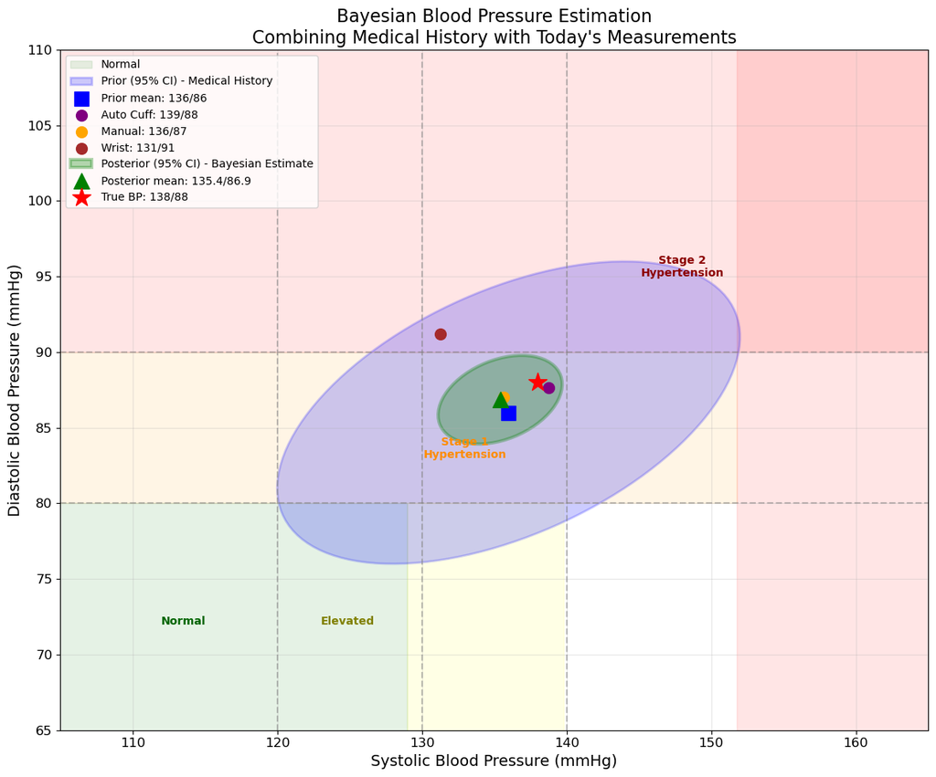

```python
fig, ax = plt.subplots(figsize=(12, 10))

# Blood pressure categories (background regions)
# Normal: <120/<80, Elevated: 120-129/<80, Stage 1: 130-139/80-89, Stage 2: ≥140/≥90
ax.axhspan(0, 80, xmin=0, xmax=0.4, alpha=0.1, color='green', label='Normal')
ax.axhspan(0, 80, xmin=0.4, xmax=0.58, alpha=0.1, color='yellow')
ax.axhspan(80, 90, xmin=0, xmax=0.78, alpha=0.1, color='orange')
ax.axhspan(90, 120, alpha=0.1, color='red')
ax.axhspan(0, 120, xmin=0.78, alpha=0.1, color='red')

# Add BP category labels
ax.text(112, 72, 'Normal', fontsize=10, color='darkgreen', fontweight='bold')
ax.text(123, 72, 'Elevated', fontsize=10, color='olive', fontweight='bold')
ax.text(133, 83, 'Stage 1\nHypertension', fontsize=10, color='darkorange', fontweight='bold', ha='center')
ax.text(148, 95, 'Stage 2\nHypertension', fontsize=10, color='darkred', fontweight='bold', ha='center')

# Plot prior distribution (medical history)
plot_confidence_ellipse(ax, mu_z, Sigma_z, n_std=2,
                        facecolor='blue', alpha=0.2, edgecolor='blue',
                        linewidth=2, label='Prior (95% CI) - Medical History')
ax.scatter(*mu_z, c='blue', s=150, marker='s', zorder=5, label=f'Prior mean: {mu_z[0]:.0f}/{mu_z[1]:.0f}')

# Plot individual device measurements
device_colors = ['purple', 'orange', 'brown']
device_names = ['Auto Cuff', 'Manual', 'Wrist']
for i, (color, name) in enumerate(zip(device_colors, device_names)):
    reading = y_observed[2*i:2*i+2]
    ax.scatter(reading[0], reading[1], c=color, s=100, marker='o',
               zorder=4, label=f'{name}: {reading[0]:.0f}/{reading[1]:.0f}')

# Plot posterior distribution (Bayesian estimate)
plot_confidence_ellipse(ax, mu_post, Sigma_post, n_std=2,
                        facecolor='green', alpha=0.3, edgecolor='green',
                        linewidth=3, label='Posterior (95% CI) - Bayesian Estimate')
ax.scatter(*mu_post, c='green', s=200, marker='^', zorder=6,
           label=f'Posterior mean: {mu_post[0]:.1f}/{mu_post[1]:.1f}')

# Plot true blood pressure
ax.scatter(*z_true, c='red', s=300, marker='*', zorder=10,
           label=f'True BP: {z_true[0]:.0f}/{z_true[1]:.0f}')

# Formatting
ax.set_xlim(105, 165)
ax.set_ylim(65, 110)
ax.set_xlabel('Systolic Blood Pressure (mmHg)', fontsize=14)
ax.set_ylabel('Diastolic Blood Pressure (mmHg)', fontsize=14)
ax.set_title('Bayesian Blood Pressure Estimation\nCombining Medical History with Today\'s Measurements', fontsize=16)
ax.legend(loc='upper left', fontsize=10)
ax.grid(True, alpha=0.3)

# Add threshold lines
ax.axvline(x=120, color='gray', linestyle='--', alpha=0.5)
ax.axvline(x=130, color='gray', linestyle='--', alpha=0.5)
ax.axvline(x=140, color='gray', linestyle='--', alpha=0.5)
ax.axhline(y=80, color='gray', linestyle='--', alpha=0.5)
ax.axhline(y=90, color='gray', linestyle='--', alpha=0.5)

plt.tight_layout()
plt.show()
```

## 5. Compare Estimation Methods

```python
# Compare different estimation approaches

# Method 1: Simple average of all readings (ignoring everything)
simple_avg = np.array([
    np.mean([y_observed[0], y_observed[2], y_observed[4]]),
    np.mean([y_observed[1], y_observed[3], y_observed[5]])
])

# Method 2: Bias-corrected average
corrected_readings = y_observed - b
bias_corrected_avg = np.array([
    np.mean([corrected_readings[0], corrected_readings[2], corrected_readings[4]]),
    np.mean([corrected_readings[1], corrected_readings[3], corrected_readings[5]])
])

# Method 3: Trust only the "gold standard" (manual device)
gold_standard = y_observed[2:4] - b[2:4]  # Device 2, bias-corrected

# Method 4: Bayesian (our approach)
bayesian = mu_post

print("=" * 60)
print("COMPARISON OF ESTIMATION METHODS")
print("=" * 60)
print(f"\nTrue BP: {z_true[0]:.0f}/{z_true[1]:.0f} mmHg")
print("\n" + "-" * 50)
methods = [
    ("Simple Average", simple_avg),
    ("Bias-Corrected Average", bias_corrected_avg),
    ("Gold Standard Only", gold_standard),
    ("Bayesian Estimate", bayesian)
]

for name, estimate in methods:
    error = np.sqrt((estimate[0]-z_true[0])**2 + (estimate[1]-z_true[1])**2)
    print(f"{name:25s}: {estimate[0]:6.1f}/{estimate[1]:.1f} mmHg  (error: {error:.2f})")

print("\n" + "=" * 60)
print("The Bayesian approach is best because it:")
print("  1. Uses prior knowledge from medical history")
print("  2. Accounts for different device accuracies")
print("  3. Corrects for known calibration biases")
print("  4. Provides uncertainty quantification (credible intervals)")
```

[output not shown]

## 6. Uncertainty Reduction Analysis

```
============================================================
UNCERTAINTY REDUCTION
============================================================

Systolic BP:
  Prior SD:     8.0 mmHg
  Posterior SD: 2.1 mmHg
  Reduction:    73%

Diastolic BP:
  Prior SD:     5.0 mmHg
  Posterior SD: 1.5 mmHg
  Reduction:    71%
```

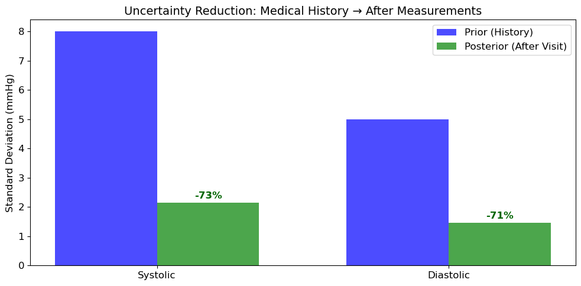

```python
# Compare prior and posterior uncertainty
prior_sd = np.sqrt(np.diag(Sigma_z))
post_sd = np.sqrt(np.diag(Sigma_post))

print("=" * 60)
print("UNCERTAINTY REDUCTION")
print("=" * 60)
print(f"\nSystolic BP:")
print(f"  Prior SD:     {prior_sd[0]:.1f} mmHg")
print(f"  Posterior SD: {post_sd[0]:.1f} mmHg")
print(f"  Reduction:    {(1 - post_sd[0]/prior_sd[0])*100:.0f}%")

print(f"\nDiastolic BP:")
print(f"  Prior SD:     {prior_sd[1]:.1f} mmHg")
print(f"  Posterior SD: {post_sd[1]:.1f} mmHg")
print(f"  Reduction:    {(1 - post_sd[1]/prior_sd[1])*100:.0f}%")

# Visualize
fig, ax = plt.subplots(figsize=(10, 5))

x = np.arange(2)
width = 0.35
labels = ['Systolic', 'Diastolic']

bars1 = ax.bar(x - width/2, prior_sd, width, label='Prior (History)', color='blue', alpha=0.7)
bars2 = ax.bar(x + width/2, post_sd, width, label='Posterior (After Visit)', color='green', alpha=0.7)

ax.set_ylabel('Standard Deviation (mmHg)', fontsize=12)
ax.set_title('Uncertainty Reduction: Medical History → After Measurements', fontsize=14)
ax.set_xticks(x)
ax.set_xticklabels(labels)
ax.legend()

# Add reduction percentages
for i, (p, q) in enumerate(zip(prior_sd, post_sd)):
    reduction = (1 - q/p) * 100
    ax.annotate(f'-{reduction:.0f}%', xy=(i + width/2, q),
                xytext=(0, 5), textcoords='offset points',
                ha='center', fontsize=12, color='darkgreen', fontweight='bold')

plt.tight_layout()
plt.show()
```

## 7. Sequential Monitoring: Multiple Visits

```python
# Simulate multiple clinic visits over time
# The patient's true BP gradually increases (developing hypertension)
n_visits = 8

# True BP trajectory (gradual increase over visits)
z_true_trajectory = np.array([
    [130 + 2*i, 82 + i] for i in range(n_visits)
])

# Store estimates
mu_trajectory = [mu_z.copy()]
Sigma_trajectory = [Sigma_z.copy()]

mu_current = mu_z.copy()
Sigma_current = Sigma_z.copy()

print("=" * 70)
print("SEQUENTIAL MONITORING ACROSS CLINIC VISITS")
print("=" * 70)
print(f"\nVisit | True BP    | Measurements (3 devices) | Bayesian Estimate | Error")
print("-" * 70)

for visit in range(n_visits):
    z_true_now = z_true_trajectory[visit]

    # Generate measurements for this visit
    y_expected_now = W @ z_true_now + b
    noise_now = np.random.multivariate_normal(np.zeros(D), Sigma_y)
    y_observed_now = y_expected_now + noise_now

    # Bayesian update
    mu_current, Sigma_current = bayes_rule_gaussian(
        y_observed_now, mu_current, Sigma_current, W, b, Sigma_y
    )

    mu_trajectory.append(mu_current.copy())
    Sigma_trajectory.append(Sigma_current.copy())

    error = np.sqrt(np.sum((mu_current - z_true_now)**2))

    # Format measurements
    meas_str = f"{y_observed_now[0]:.0f}/{y_observed_now[1]:.0f}, {y_observed_now[2]:.0f}/{y_observed_now[3]:.0f}, {y_observed_now[4]:.0f}/{y_observed_now[5]:.0f}"

    print(f"  {visit+1:2d}  | {z_true_now[0]:.0f}/{z_true_now[1]:.0f}    | {meas_str:28s} | {mu_current[0]:.1f}/{mu_current[1]:.1f}          | {error:.1f}")
```

```
======================================================================
SEQUENTIAL MONITORING ACROSS CLINIC VISITS
======================================================================

Visit | True BP    | Measurements (3 devices) | Bayesian Estimate | Error
----------------------------------------------------------------------
   1  | 130/82    | 128/80, 131/82, 118/79       | 127.9/80.3          | 2.7
   2  | 132/83    | 140/84, 135/85, 130/79       | 131.6/81.6          | 1.5
   3  | 134/84    | 139/87, 138/83, 135/93       | 133.3/82.5          | 1.6
   4  | 136/85    | 136/83, 137/85, 138/84       | 134.0/82.8          | 3.0
   5  | 138/86    | 130/85, 144/86, 139/89       | 134.8/83.3          | 4.2
   6  | 140/87    | 147/92, 141/88, 137/84       | 136.0/84.0          | 5.0
   7  | 142/88    | 144/87, 145/92, 141/85       | 137.1/84.7          | 6.0
   8  | 144/89    | 152/90, 147/91, 139/91       | 138.2/85.4          | 6.8
```

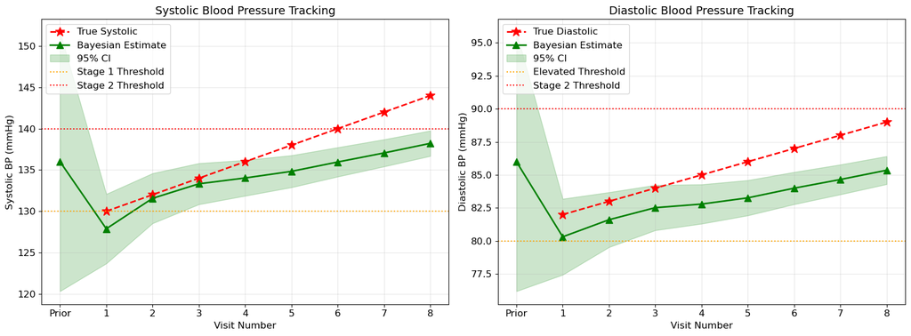

```python
# Visualize the tracking over time
fig, axes = plt.subplots(1, 2, figsize=(16, 6))

visits = np.arange(n_visits + 1)  # 0 = prior, 1-8 = visits
mu_traj = np.array(mu_trajectory)

# Left plot: Systolic tracking
ax1 = axes[0]
ax1.plot(visits[1:], z_true_trajectory[:, 0], 'r--', linewidth=2, marker='*', markersize=12, label='True Systolic')
ax1.plot(visits, mu_traj[:, 0], 'g-', linewidth=2, marker='^', markersize=8, label='Bayesian Estimate')

# Add uncertainty bands
sds = np.array([np.sqrt(S[0,0]) for S in Sigma_trajectory])
ax1.fill_between(visits, mu_traj[:,0] - 1.96*sds, mu_traj[:,0] + 1.96*sds,
                 alpha=0.2, color='green', label='95% CI')

ax1.axhline(y=130, color='orange', linestyle=':', label='Stage 1 Threshold')
ax1.axhline(y=140, color='red', linestyle=':', label='Stage 2 Threshold')
ax1.set_xlabel('Visit Number', fontsize=12)
ax1.set_ylabel('Systolic BP (mmHg)', fontsize=12)
ax1.set_title('Systolic Blood Pressure Tracking', fontsize=14)
ax1.legend(loc='upper left')
ax1.grid(True, alpha=0.3)
ax1.set_xticks(visits)
ax1.set_xticklabels(['Prior'] + [f'{i}' for i in range(1, n_visits+1)])

# Right plot: Diastolic tracking
ax2 = axes[1]
ax2.plot(visits[1:], z_true_trajectory[:, 1], 'r--', linewidth=2, marker='*', markersize=12, label='True Diastolic')
ax2.plot(visits, mu_traj[:, 1], 'g-', linewidth=2, marker='^', markersize=8, label='Bayesian Estimate')

sds_d = np.array([np.sqrt(S[1,1]) for S in Sigma_trajectory])
ax2.fill_between(visits, mu_traj[:,1] - 1.96*sds_d, mu_traj[:,1] + 1.96*sds_d,
                 alpha=0.2, color='green', label='95% CI')

ax2.axhline(y=80, color='orange', linestyle=':', label='Elevated Threshold')
ax2.axhline(y=90, color='red', linestyle=':', label='Stage 2 Threshold')
ax2.set_xlabel('Visit Number', fontsize=12)
ax2.set_ylabel('Diastolic BP (mmHg)', fontsize=12)
ax2.set_title('Diastolic Blood Pressure Tracking', fontsize=14)
ax2.legend(loc='upper left')
ax2.grid(True, alpha=0.3)
ax2.set_xticks(visits)
ax2.set_xticklabels(['Prior'] + [f'{i}' for i in range(1, n_visits+1)])

plt.tight_layout()
plt.show()
```

## 8. Clinical Interpretation: When to Worry?

The Bayesian approach provides not just a point estimate but a full probability distribution. This allows us to ask clinically relevant questions:

```python
from scipy.stats import multivariate_normal, norm

# Using our original single-visit posterior
print("=" * 60)
print("CLINICAL RISK ASSESSMENT")
print("=" * 60)
print(f"\nBayesian Estimate: {mu_post[0]:.1f}/{mu_post[1]:.1f} mmHg")
print(f"95% CI Systolic:  [{mu_post[0]-1.96*np.sqrt(Sigma_post[0,0]):.0f}, {mu_post[0]+1.96*np.sqrt(Sigma_post[0,0]):.0f}]")
print(f"95% CI Diastolic: [{mu_post[1]-1.96*np.sqrt(Sigma_post[1,1]):.0f}, {mu_post[1]+1.96*np.sqrt(Sigma_post[1,1]):.0f}]")

# Compute probability of being in each BP category
# Marginal distributions
systolic_dist = norm(mu_post[0], np.sqrt(Sigma_post[0,0]))
diastolic_dist = norm(mu_post[1], np.sqrt(Sigma_post[1,1]))

# P(Systolic ≥ 140) - Stage 2 systolic
p_sys_stage2 = 1 - systolic_dist.cdf(140)

# P(Systolic ≥ 130) - Stage 1+ systolic
p_sys_stage1 = 1 - systolic_dist.cdf(130)

# P(Diastolic ≥ 90) - Stage 2 diastolic
p_dia_stage2 = 1 - diastolic_dist.cdf(90)

# P(Diastolic ≥ 80) - Elevated diastolic
p_dia_elevated = 1 - diastolic_dist.cdf(80)

print("\n" + "-" * 40)
print("Probability of Hypertension:")
print("-" * 40)
print(f"P(Systolic ≥ 130, Stage 1+):  {p_sys_stage1*100:5.1f}%")
print(f"P(Systolic ≥ 140, Stage 2):   {p_sys_stage2*100:5.1f}%")
print(f"P(Diastolic ≥ 80, Elevated):  {p_dia_elevated*100:5.1f}%")
print(f"P(Diastolic ≥ 90, Stage 2):   {p_dia_stage2*100:5.1f}%")

print("\n" + "=" * 60)
if p_sys_stage1 > 0.75 or p_dia_elevated > 0.75:
    print("RECOMMENDATION: High probability of hypertension.")
    print("Consider lifestyle modifications and follow-up monitoring.")
elif p_sys_stage1 > 0.25 or p_dia_elevated > 0.25:
    print("RECOMMENDATION: Moderate risk. Schedule follow-up visit.")
else:
    print("RECOMMENDATION: Blood pressure appears normal.")
```

```
============================================================
CLINICAL RISK ASSESSMENT
============================================================

Bayesian Estimate: 135.4/86.9 mmHg
95% CI Systolic:  [131, 140]
95% CI Diastolic: [84, 90]

----------------------------------------
Probability of Hypertension:
----------------------------------------
P(Systolic ≥ 130, Stage 1+):   99.4%
P(Systolic ≥ 140, Stage 2):     1.6%
P(Diastolic ≥ 80, Elevated):  100.0%
P(Diastolic ≥ 90, Stage 2):     1.6%

============================================================
RECOMMENDATION: High probability of hypertension.
Consider lifestyle modifications and follow-up monitoring.
```

## 9. Understanding the Formulas

### Key Insights from Chapter 3.3.1:

**1. Posterior Precision = Prior Precision + Data Precision** $$\boldsymbol{\Sigma}_{z|y}^{-1} = \underbrace{\boldsymbol{\Sigma}_z^{-1}}_{\text{prior precision}} + \underbrace{\mathbf{W}^T \boldsymbol{\Sigma}_y^{-1} \mathbf{W}}_{\text{data precision}}$$

The posterior is always more certain than the prior (higher precision = lower variance).

**2. Posterior Mean = Weighted Combination** $$\boldsymbol{\mu}_{z|y} = \boldsymbol{\Sigma}_{z|y} \left[ \mathbf{W}^T \boldsymbol{\Sigma}_y^{-1} (\mathbf{y} - \mathbf{b}) + \boldsymbol{\Sigma}_z^{-1} \boldsymbol{\mu}_z \right]$$

The posterior mean is a precision-weighted average of:

- The measurements' "suggestion" for true BP (corrected for bias)
- The prior's belief from medical history

**3. Clinical Interpretation**

- More precise devices (lower $\Sigma_y$) get more weight
- Strong prior (from many past visits) pulls estimate toward history
- Uncertain prior (new patient) lets measurements dominate

```python
# Demonstrate the precision addition property
Sigma_z_inv = np.linalg.inv(Sigma_z)
Sigma_y_inv = np.linalg.inv(Sigma_y)
data_precision = W.T @ Sigma_y_inv @ W

print("=" * 60)
print("PRECISION ANALYSIS (Eq. 3.37)")
print("=" * 60)
print(f"\nPrior precision Σ_z^(-1) =\n{Sigma_z_inv}")
print(f"\nData precision W^T Σ_y^(-1) W =\n{data_precision}")
print(f"\nPosterior precision Σ_{{z|y}}^(-1) =\n{Sigma_z_inv + data_precision}")
print(f"\n→ Information from 3 devices adds to prior knowledge!")
print(f"→ Diagonal elements increased: more certainty about both systolic and diastolic")
```

```
============================================================
PRECISION ANALYSIS (Eq. 3.37)
============================================================

Prior precision Σ_z^(-1) =
[[ 0.02083333 -0.01666667]
 [-0.01666667  0.05333333]]

Data precision W^T Σ_y^(-1) W =
[[ 0.2265625 -0.109375 ]
 [-0.109375   0.4765625]]

Posterior precision Σ_{z|y}^(-1) =
[[ 0.24739583 -0.12604167]
 [-0.12604167  0.52989583]]

→ Information from 3 devices adds to prior knowledge!
→ Diagonal elements increased: more certainty about both systolic and diastolic
```

## Summary

This notebook demonstrated **Bayes Rule for Gaussians** (Chapter 3.3.1) with a clinical blood pressure estimation scenario:

1. **Prior (Medical History)**: Patient's BP from previous visits provides baseline knowledge
2. **Likelihood (Measurements)**: Multiple devices with different accuracies and biases
3. **Posterior (Best Estimate)**: Optimally combines history with today's readings

### Why Bayesian BP Estimation is Better:

| Simple Average | Bayesian Approach |
| --- | --- |
| Ignores medical history | Incorporates prior visits |
| Treats all devices equally | Weights by device precision |
| Ignores calibration biases | Corrects for known biases |
| Point estimate only | Full uncertainty quantification |
| Can't assess risk | Computes P(hypertension) |

### Key Takeaways:

- **Precision adds**: Each measurement increases certainty
- **Quality matters**: Better devices contribute more to the estimate
- **Sequential updates**: Each visit's posterior becomes next visit's prior
- **Clinical utility**: Uncertainty enables risk-based decision making